# CAR CONDITION EVALUATION USING MACHINE LEARNING for Informed Purchasing Decisions

NUNNA RAMA CHANDU

2023-04-04

INTRODUCTION:

Evaluating the conditions of a car before purchasing plays a crucial role in decision making. Manually, classifying a good or acceptable condition car from an unacceptable conditioned car is time-consuming and labor-intensive. We can leverage Machine Learning techniques to develop an automatic system for car evaluation.A decision to buy a car or not according to its physical qualifications is being discussed in this project. The dataset is taken from kaggle. This data set is composed of 1727 rows and 7 different attributes. Based on the information provided by the data set, each car will be classified, using the six attributes, into unacceptable, acceptable, good or very good. The variables of the dataset are as follows:

Buying Price : v-high, high, med, low

Maintenance Cost : v-high, high, med, low

Number of doors : 2, 3, 4, 5-more

Number of persons : 2, 4, more

lug_boot : small, med, big

Safety : low, med, high

Decision : unacceptable, acceptable, good or very good

Through this project we aim to :

Analyse the different parameters for the car evaluation

Plot the visualizations for better understanding of the dataset

Build the model using supervised learning methods like Decision Tree and Random Forest

Understand and compare the accuracy of the both models

Packages Required:

```r
#load the required packages
library(ggplot2)
library(gplots)
library(dplyr)
library(tidyverse)
library(reshape2)
library(rpart)
library(rpart.plot)
library(caret)
library(randomForest)
```

Importing the dataset

```r
#load the dataset
library(readxl)
car_data <- read_excel("car_evaluation.xlsx")
dim(car_data)
```

```
## [1] 1727    7
```

```r
summary(car_data)
```

```
##   vhigh...1          vhigh...2            2...3              2...4
##  Length:1727        Length:1727        Length:1727        Length:1727
##  Class :character   Class :character   Class :character   Class :character
##  Mode  :character   Mode  :character   Mode  :character   Mode  :character
##     small               low               unacc
##  Length:1727        Length:1727        Length:1727
##  Class :character   Class :character   Class :character
##  Mode  :character   Mode  :character   Mode  :character
```

Exploratory Data Analysis:

examining the dataset using head() and str() functions

```r
head(car_data,10)
```

```
## # A tibble: 10 × 7
##    vhigh...1 vhigh...2 `2...3` `2...4` small low   unacc
##    <chr>     <chr>     <chr>   <chr>   <chr> <chr> <chr>
##  1 vhigh     vhigh     2       2       small med   unacc
##  2 vhigh     vhigh     2       2       small high  unacc
##  3 vhigh     vhigh     2       2       med   low   unacc
##  4 vhigh     vhigh     2       2       med   med   unacc
##  5 vhigh     vhigh     2       2       med   high  unacc
##  6 vhigh     vhigh     2       2       big   low   unacc
##  7 vhigh     vhigh     2       2       big   med   unacc
##  8 vhigh     vhigh     2       2       big   high  unacc
##  9 vhigh     vhigh     2       4       small low   unacc
## 10 vhigh     vhigh     2       4       small med   unacc
```

```r
str(car_data)
```

```
## tibble [1,727 × 7] (S3: tbl_df/tbl/data.frame)
##  $ vhigh...1: chr [1:1727] "vhigh" "vhigh" "vhigh" "vhigh" ...
##  $ vhigh...2: chr [1:1727] "vhigh" "vhigh" "vhigh" "vhigh" ...
##  $ 2...3    : chr [1:1727] "2" "2" "2" "2" ...
##  $ 2...4    : chr [1:1727] "2" "2" "2" "2" ...
##  $ small    : chr [1:1727] "small" "small" "med" "med" ...
##  $ low      : chr [1:1727] "med" "high" "low" "med" ...
##  $ unacc    : chr [1:1727] "unacc" "unacc" "unacc" "unacc" ...
```

Inference:

We see that the column names are not descriptive, so we assign new column names based on the dataset and also check if there are any missing values in the dataset.

```r
colnames(car_data)=c("buying","maint","doors","persons","lug_boot","safety","class")
colSums(is.na(car_data))
```

```
##   buying    maint    doors  persons lug_boot   safety    class
##        0        0        0        0        0        0        0
```

Inference:

The dataset looks clean with no missing values. Basic insights of the data can be obtained by exploring the data through visualizations.

Bar charts:

Let us examine how the cars are classified as good, acceptable or unacceptable based on different car parameters using bar charts.

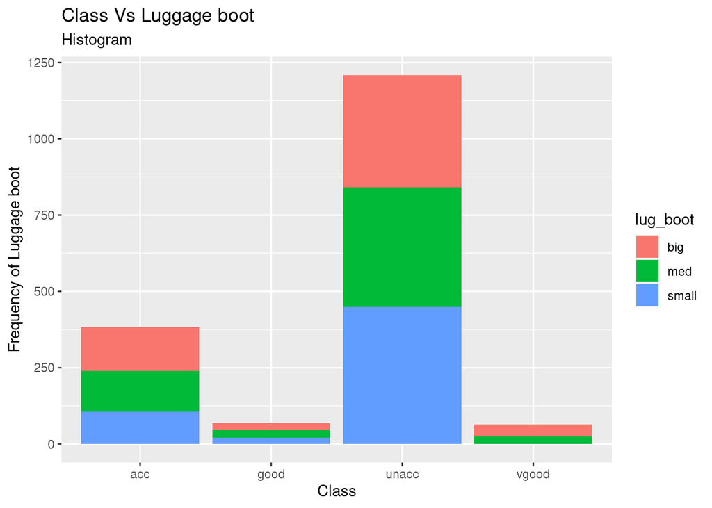

```r
ggplot(car_data,aes(x=class,fill=lug_boot))+geom_histogram(stat="count")+labs(title="Class Vs Luggage boot",subtitle="Histogram",y="Frequency of Luggage boot",x="Class")
```

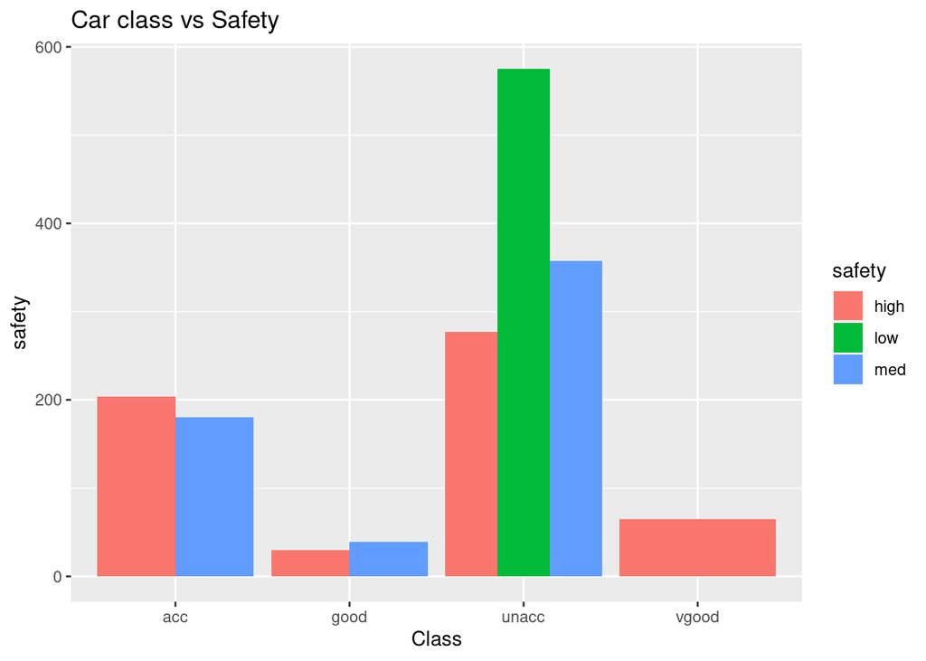

```r
ggplot(car_data, aes(class , fill = safety )) +
  geom_bar(position = position_dodge()) +
  ggtitle("Car class vs Safety") +
  xlab("Class") +
  ylab("safety")
```

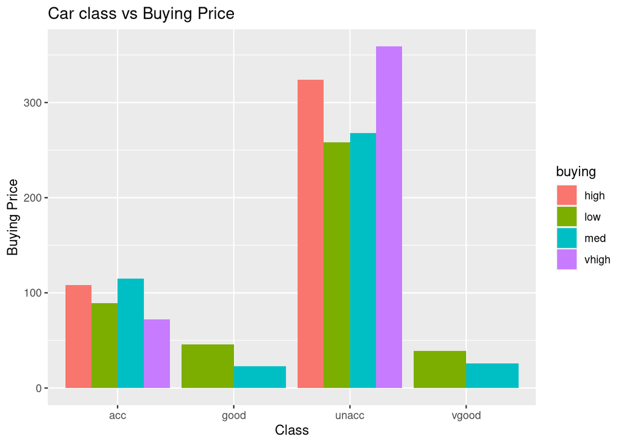

```r
ggplot(car_data, aes(class , fill = buying )) +
  geom_bar(position = position_dodge()) +
  ggtitle("Car class vs Buying Price") +
  xlab("Class") +
  ylab("Buying Price")
```

Density Plots:

A Density Plot visualizes the distribution of data over a continuous interval or time period. Let us check how the density plot looks like for different paramaters

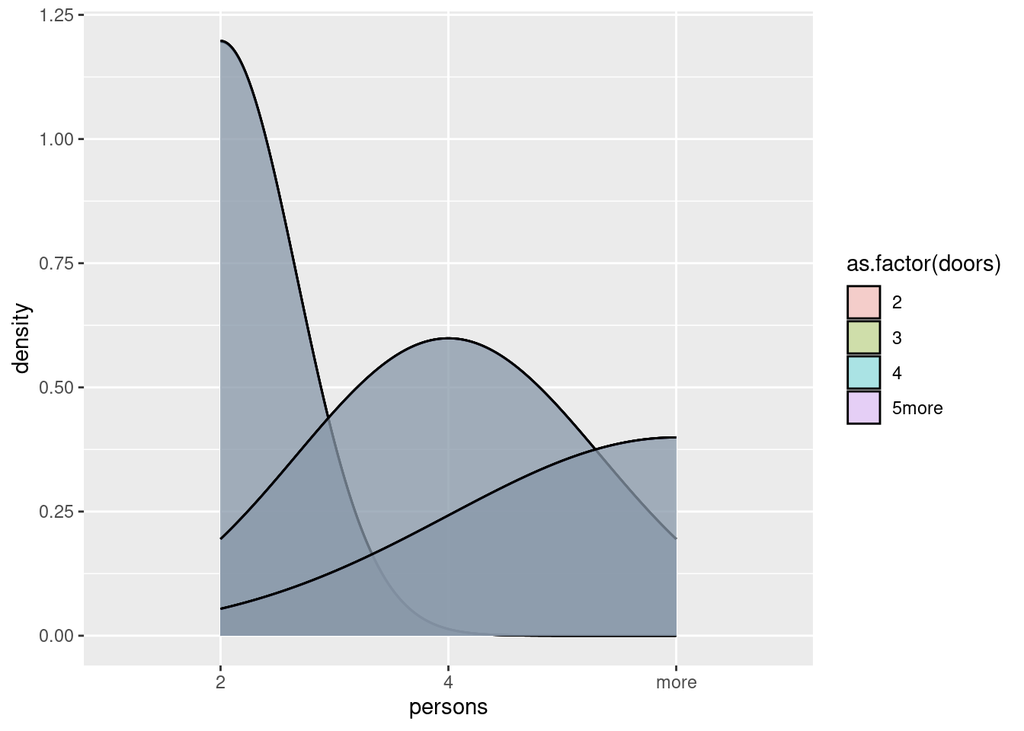

```r
ggplot(data = car_data,aes(fill=as.factor(doors),x=persons))+geom_density(alpha=0.3)
```

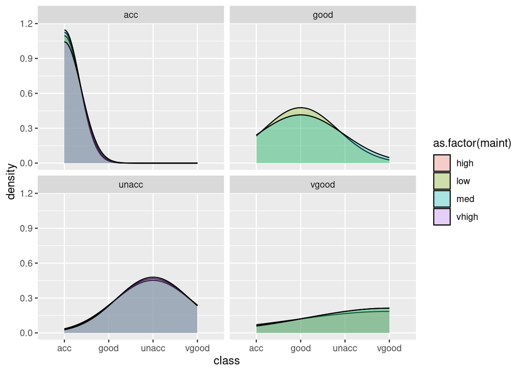

```r
ggplot(data = car_data,aes(fill=as.factor(maint),x=class))+geom_density(alpha=0.3)+facet_wrap(~class)
```

Model 1: Decision Tree

Decision trees generate classification models in tree forms. This form helps to understand the decision hierarchy and relations between the attributes by visualizing as using the possible outcomes of each attribute as a branch of the tree. Lets start with splitting the dataset into training and testing data sets,as being 70% of the data set is for training and 30% is for testing processes

```r
set.seed(100)
classValues<-as.vector(car_data$class)
train_test_split <- createDataPartition(y=classValues, p=0.7,list =FALSE)
train_data <-car_data[train_test_split,]
test_data <- car_data[-train_test_split,]
summary(train_data)
```

```
##     buying             maint              doors             persons
##  Length:1211        Length:1211        Length:1211        Length:1211
##  Class :character   Class :character   Class :character   Class :character
##  Mode  :character   Mode  :character   Mode  :character   Mode  :character
##    lug_boot            safety             class
##  Length:1211        Length:1211        Length:1211
##  Class :character   Class :character   Class :character
##  Mode  :character   Mode  :character   Mode  :character
```

```r
summary(test_data)
```

```
##     buying             maint              doors             persons
##  Length:516         Length:516         Length:516         Length:516
##  Class :character   Class :character   Class :character   Class :character
##  Mode  :character   Mode  :character   Mode  :character   Mode  :character
##    lug_boot            safety             class
##  Length:516         Length:516         Length:516
##  Class :character   Class :character   Class :character
##  Mode  :character   Mode  :character   Mode  :character
```

```r
train_control <- trainControl(method = "repeatedcv", number = 10, repeats = 3)
set.seed(3333)
decision_tree <- train(class ~., data = train_data, method = "rpart", parms = list(split = "information"), trControl = train_control, tuneLength = 10)
decision_tree
```

```
## CART
##
## 1211 samples
##    6 predictor
##    4 classes: 'acc', 'good', 'unacc', 'vgood'
##
## No pre-processing
## Resampling: Cross-Validated (10 fold, repeated 3 times)
## Summary of sample sizes: 1090, 1092, 1089, 1089, 1089, 1090, ...
## Resampling results across tuning parameters:
##
##   cp           Accuracy   Kappa
##   0.002747253  0.8353544  0.6469669
##   0.005494505  0.8411466  0.6622520
##   0.008241758  0.8356138  0.6422486
##   0.009615385  0.8215842  0.6060176
##   0.010989011  0.8072517  0.5771825
##   0.013736264  0.8089069  0.5825292
##   0.016483516  0.8075408  0.5780949
##   0.019230769  0.8061656  0.5742093
##   0.063186813  0.7890372  0.5559210
##   0.075549451  0.7106902  0.1995604
##
## Accuracy was used to select the optimal model using the largest value.
## The final value used for the model was cp = 0.005494505.
```

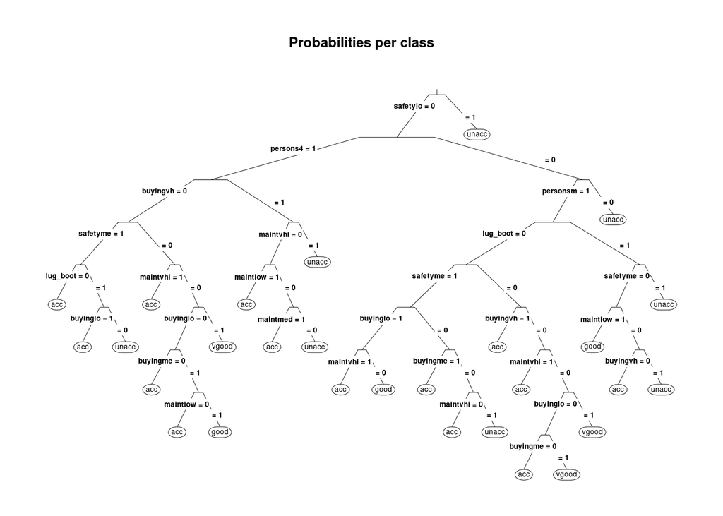

```r
# plotting decision tree
prp(decision_tree$finalModel, type=3, main= "Probabilities per class")
```

Inference:

The classification process is done but it is not obvious how accurate the model succeeded. The predictions of train and test sets are being compared with the data of original train and test set and their accuracy values are gathered as 87.3% for train set and 87.5% for the test set. The accuracy on the test set is the base for the study to evaluate how well is the performance of the model on the data it did not process before.

```r
# prediction of train data
train_pred <- predict(decision_tree, train_data)
head(train_pred)
```

```
## [1] unacc unacc unacc unacc unacc unacc
## Levels: acc good unacc vgood
```

```r
table(train_pred, train_data$class)
```

```
##
## train_pred acc good unacc vgood
##      acc   227   18    75     4
##      good   13   24     4     3
##      unacc  18    0   768     0
##      vgood  11    7     0    39
```

```r
mean(train_pred  == train_data$class)
```

```
## [1] 0.8736581
```

```r
# prediction of test data
test_pred <- predict(decision_tree, test_data)
head(test_pred)
```

```
## [1] unacc unacc unacc unacc unacc unacc
## Levels: acc good unacc vgood
```

```r
table(test_pred, test_data$class)
```

```
##
## test_pred acc good unacc vgood
##     acc    99   10    25     2
##     good    3    2     0     3
##     unacc   8    0   337     0
##     vgood   5    8     0    14
```

```r
mean(test_pred  == test_data$class)
```

```
## [1] 0.875969
```

The statistical variables are also calculated to understand the success of the mode by building a confusion matrix.

```r
confusionMatrix(test_pred, as.factor(test_data$class))
```

```
## Confusion Matrix and Statistics
##
##           Reference
## Prediction acc good unacc vgood
##      acc    99   10    25     2
##      good    3    2     0     3
##      unacc   8    0   337     0
##      vgood   5    8     0    14
##
## Overall Statistics
##
##                Accuracy : 0.876
##                  95% CI : (0.8444, 0.9032)
##     No Information Rate : 0.7016
##     P-Value [Acc > NIR] : < 2.2e-16
##
##                   Kappa : 0.7359
##
##  Mcnemar's Test P-Value : NA
##
## Statistics by Class:
##
##                      Class: acc Class: good Class: unacc Class: vgood
## Sensitivity              0.8609    0.100000       0.9309      0.73684
## Specificity              0.9077    0.987903       0.9481      0.97384
## Pos Pred Value           0.7279    0.250000       0.9768      0.51852
## Neg Pred Value           0.9579    0.964567       0.8538      0.98978
## Prevalence               0.2229    0.038760       0.7016      0.03682
## Detection Rate           0.1919    0.003876       0.6531      0.02713
## Detection Prevalence     0.2636    0.015504       0.6686      0.05233
## Balanced Accuracy        0.8843    0.543952       0.9395      0.85534
```

```r
confusionMatrix(test_pred, as.factor(test_data$class), mode = "prec_recall", positive="1")
```

```
## Confusion Matrix and Statistics
##
##           Reference
## Prediction acc good unacc vgood
##      acc    99   10    25     2
##      good    3    2     0     3
##      unacc   8    0   337     0
##      vgood   5    8     0    14
##
## Overall Statistics
##
##                Accuracy : 0.876
##                  95% CI : (0.8444, 0.9032)
##     No Information Rate : 0.7016
##     P-Value [Acc > NIR] : < 2.2e-16
##
##                   Kappa : 0.7359
##
##  Mcnemar's Test P-Value : NA
##
## Statistics by Class:
##
##                      Class: acc Class: good Class: unacc Class: vgood
## Precision                0.7279    0.250000       0.9768      0.51852
## Recall                   0.8609    0.100000       0.9309      0.73684
## F1                       0.7888    0.142857       0.9533      0.60870
## Prevalence               0.2229    0.038760       0.7016      0.03682
## Detection Rate           0.1919    0.003876       0.6531      0.02713
## Detection Prevalence     0.2636    0.015504       0.6686      0.05233
## Balanced Accuracy        0.8843    0.543952       0.9395      0.85534
```

Inference:

We see that the accuracy of the model is 87.6 %

Model 2: Random Forest

Random forests or random decision forests is an ensemble learning method for classification, regression and other tasks that operates by constructing a multitude of decision trees at training time. After decision tree algorithm, to increase the accuracy of the model, we build the model using random forest method.

```r
random_forest <- randomForest(as.factor(class)~., data = train_data, importance = TRUE)
random_forest
```

```
##
## Call:
##  randomForest(formula = as.factor(class) ~ ., data = train_data,      importance = TRUE)
##                Type of random forest: classification
##                      Number of trees: 500
## No. of variables tried at each split: 2
##
##         OOB estimate of  error rate: 3.96%
## Confusion matrix:
##       acc good unacc vgood class.error
## acc   252    1    15     1 0.063197026
## good   21   28     0     0 0.428571429
## unacc   7    0   840     0 0.008264463
## vgood   3    0     0    43 0.065217391
```

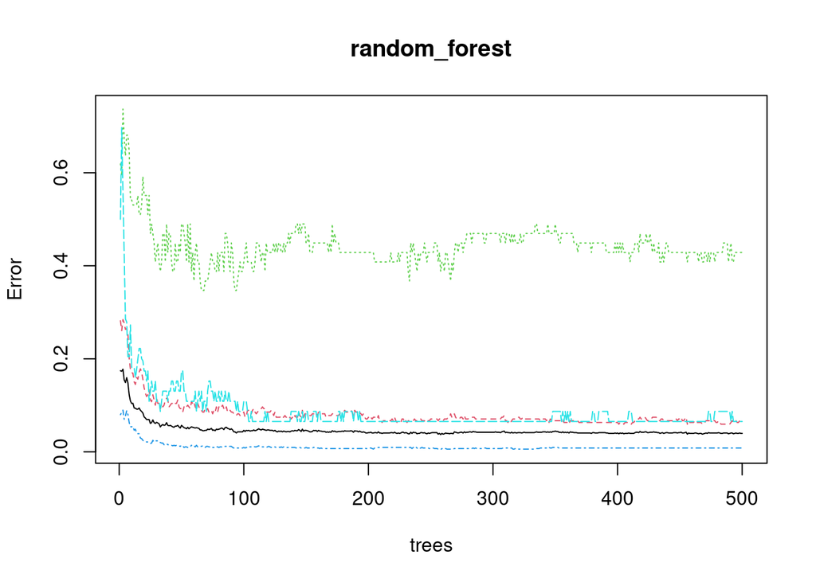

```r
plot(random_forest)
```

Inference:

The “trees” and “error” refers to the number of decision trees in the forest and out-of-bag (OOB) error rate.

In a random forest plot, the number of trees is usually plotted on the x-axis and the OOB error rate is plotted on the y-axis. The plot shows how the OOB error rate changes ad the number of tress in the forest increases. Typically, the OOB error rate decreases with increasing number of trees.

The number of trees is an important hyperparameter in random forest and determines the size of the forest. Increasing the number of trees can improve the accuracy of the classification, but may also increase the overfitting.

The OOB error rate is an estimate of the generalization error of the random forest. can be used to evaluate the performance of the random forest. A lower OOB error rate indicates a better generalization performance of the model

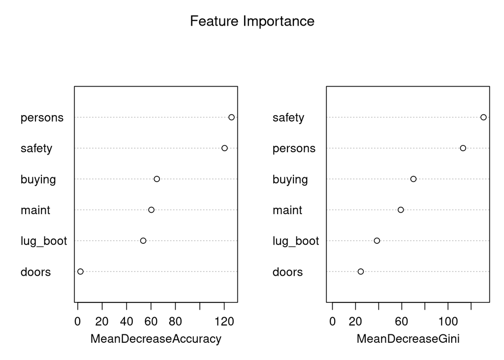

```r
varImpPlot(random_forest, main = 'Feature Importance')
```

Inference:

Mean decrease accuracy measures the reduction in accuracy achieved by each feature when the feature is randomly permuted.

We again check the prediction of train and test sets with the data of original train and test set.

```r
#fine tuning the model
random_forest_1 <- randomForest(as.factor(class)~., data = train_data, ntree = 500, mtry = 3, importance = TRUE)
random_forest_1
```

```
##
## Call:
##  randomForest(formula = as.factor(class) ~ ., data = train_data,      ntree = 500, mtry = 3, importance = TRUE)
##                Type of random forest: classification
##                      Number of trees: 500
## No. of variables tried at each split: 3
##
##         OOB estimate of  error rate: 2.48%
## Confusion matrix:
##       acc good unacc vgood class.error
## acc   257    4     7     1  0.04460967
## good    7   41     0     1  0.16326531
## unacc   9    0   838     0  0.01062574
## vgood   1    0     0    45  0.02173913
```

```r
#prediction on train data set
train_pred1 <-predict(random_forest_1, train_data, type = "class")
table(train_pred1, train_data$class)
```

```
##
## train_pred1 acc good unacc vgood
##       acc   269    0     0     0
##       good    0   49     0     0
##       unacc   0    0   847     0
##       vgood   0    0     0    46
```

```r
mean(train_pred1 == train_data$class)
```

```
## [1] 1
```

```r
#prediction on test data set
test_pred1 <-predict(random_forest_1, test_data, type = "class")
table(test_pred1, test_data$class)
```

```
##
## test_pred1 acc good unacc vgood
##      acc   111    2     1     1
##      good    0   18     0     3
##      unacc   4    0   361     0
##      vgood   0    0     0    15
```

```r
mean(test_pred1==test_data$class)
```

```
## [1] 0.9786822
```

The statistical variables are also calculated to understand the success of the mode by building a confusion matrix.

```r
confusionMatrix(test_pred1, as.factor(test_data$class))
```

```
## Confusion Matrix and Statistics
##
##           Reference
## Prediction acc good unacc vgood
##      acc   111    2     1     1
##      good    0   18     0     3
##      unacc   4    0   361     0
##      vgood   0    0     0    15
##
## Overall Statistics
##
##                Accuracy : 0.9787
##                  95% CI : (0.9622, 0.9893)
##     No Information Rate : 0.7016
##     P-Value [Acc > NIR] : < 2.2e-16
##
##                   Kappa : 0.9528
##
##  Mcnemar's Test P-Value : NA
##
## Statistics by Class:
##
##                      Class: acc Class: good Class: unacc Class: vgood
## Sensitivity              0.9652     0.90000       0.9972      0.78947
## Specificity              0.9900     0.99395       0.9740      1.00000
## Pos Pred Value           0.9652     0.85714       0.9890      1.00000
## Neg Pred Value           0.9900     0.99596       0.9934      0.99202
## Prevalence               0.2229     0.03876       0.7016      0.03682
## Detection Rate           0.2151     0.03488       0.6996      0.02907
## Detection Prevalence     0.2229     0.04070       0.7074      0.02907
## Balanced Accuracy        0.9776     0.94698       0.9856      0.89474
```

```r
confusionMatrix(test_pred1, as.factor(test_data$class), mode = "prec_recall", positive="1")
```

```
## Confusion Matrix and Statistics
##
##           Reference
## Prediction acc good unacc vgood
##      acc   111    2     1     1
##      good    0   18     0     3
##      unacc   4    0   361     0
##      vgood   0    0     0    15
##
## Overall Statistics
##
##                Accuracy : 0.9787
##                  95% CI : (0.9622, 0.9893)
##     No Information Rate : 0.7016
##     P-Value [Acc > NIR] : < 2.2e-16
##
##                   Kappa : 0.9528
##
##  Mcnemar's Test P-Value : NA
##
## Statistics by Class:
##
##                      Class: acc Class: good Class: unacc Class: vgood
## Precision                0.9652     0.85714       0.9890      1.00000
## Recall                   0.9652     0.90000       0.9972      0.78947
## F1                       0.9652     0.87805       0.9931      0.88235
## Prevalence               0.2229     0.03876       0.7016      0.03682
## Detection Rate           0.2151     0.03488       0.6996      0.02907
## Detection Prevalence     0.2229     0.04070       0.7074      0.02907
## Balanced Accuracy        0.9776     0.94698       0.9856      0.89474
```

Inference:

We see that the accuracy of the model has improved and is 97.87 %

Model 3: Naive Bayes

```r
library(e1071)
```

```r
set.seed(123) # for reproducibility
train_index <- sample(nrow(car_data), 0.7 * nrow(car_data))
train_data <- car_data[train_index, ]
test_data <- car_data[-train_index, ]
```

```r
nb_model <- naiveBayes(class ~ buying + maint + doors + persons + lug_boot + safety, data = train_data)
```

```r
nb_pred <- predict(nb_model, newdata = test_data)
accuracy <- sum(nb_pred == test_data$class) / nrow(test_data)
print(paste("Naive Bayes accuracy:", round(accuracy, 4)))
```

```
## [1] "Naive Bayes accuracy: 0.8247"
```

Conclusion:

This dataset was divided into four classes as very good, good, acceptable and unacceptable cars considering the six different attributes which are buying price, maintenance, number of doors, capacity in terms of persons to carry, size of luggage boot and the estimated safety value. The model we built using naive bayes and decision tree had the accuracy of 82.47% and 87.6%. and to increase the accuracy we built model using random Forest method and the accuracy improved to 97.8 %.